# Bellabit-Fitbit Case Study

Ana R. Castillo

2023-06-18

## Case Project Introduction:

In this analysis, I examined the Fitbit data for Bellabit’s product. The goal was to identify trends among Fitbit users and provide recommendations to improve user interaction. The analysis was conducted following the data analysis process, which consists of five steps: Ask, Prepare, Process, Analyze, and Share.

## 1. Ask

In the “Ask” phase, I clarified the objectives and questions to be answered through the analysis. The main questions I aimed to address were:

1. What are some trends among users with Fitbit usage?
2. How can these trends improve user interaction?
3. How can these findings help Bellabit as a company?

………………………………………………………………………..

## 2. Prepare

#### Cleaning daily_activity table

```r
daily_activity <- daily_activity %>%
  clean_names() %>%
  rename(date = activity_date) %>%
  mutate(date = mdy(date)) %>%
  mutate(weekday = wday(date, label = TRUE))

head(daily_activity)
```

```
##           id       date total_steps total_distance tracker_distance
## 1 1503960366 2016-04-12       13162           8.50             8.50
## 2 1503960366 2016-04-13       10735           6.97             6.97
## 3 1503960366 2016-04-14       10460           6.74             6.74
## 4 1503960366 2016-04-15        9762           6.28             6.28
## 5 1503960366 2016-04-16       12669           8.16             8.16
## 6 1503960366 2016-04-17        9705           6.48             6.48
##   logged_activities_distance very_active_distance moderately_active_distance
## 1                          0                 1.88                       0.55
## 2                          0                 1.57                       0.69
## 3                          0                 2.44                       0.40
## 4                          0                 2.14                       1.26
## 5                          0                 2.71                       0.41
## 6                          0                 3.19                       0.78
##   light_active_distance sedentary_active_distance very_active_minutes
```

[output cut: 20 more lines]

```r
daily_activity %>%  count(id = n_distinct(id))
```

```
##   id   n
## 1 33 940
```

In this code, I am performing a series of operations on the “daily_activity” dataset. First, I clean the column names and rename the “activity_date” column to “date”. Then, I convert the “date” column to a proper date format using the “mdy” function. Finally, I add a new column called “weekday” which represents the weekday corresponding to each date using the “wday” function. After these transformations, I display the first few rows of the modified dataset and calculate the number of distinct users by counting the unique values in the “id” column. This code helps analyze and summarize the daily activity data by standardizing column names, transforming date formats, and providing insights on user counts.

#### Cleaning sleep_day table

```r
sleep_day <- sleep_day %>%
  clean_names() %>%
  rename(date = sleep_day) %>%
  mutate(date = as.Date(date, format = "%m/%d/%Y %I:%M:%S %p"))

head(sleep_day)
```

```
## # A tibble: 6 × 5
##         id date       total_sleep_records total_minutes_asleep total_time_in_bed
##      <dbl> <date>                   <dbl>                <dbl>             <dbl>
## 1   1.50e9 2016-04-12                   1                  327               346
## 2   1.50e9 2016-04-13                   2                  384               407
## 3   1.50e9 2016-04-15                   1                  412               442
## 4   1.50e9 2016-04-16                   2                  340               367
## 5   1.50e9 2016-04-17                   1                  700               712
## 6   1.50e9 2016-04-19                   1                  304               320
```

```r
sleep_day %>% count(id = n_distinct(id))
```

```
## # A tibble: 1 × 2
##      id     n
##   <int> <int>
## 1    24   413
```

In this code snippet, I am working with the “sleep_day” dataset. First, I clean the column names and rename the “sleep_day” column to “date”. Then, I convert the “date” column to the Date format using the specified format (“%m/%d/%Y %I:%M:%S %p”) with the “as.Date” function.. Additionally, I calculate the number of distinct users by counting the unique values in the “id” column in the “sleep_day” dataset. This code snippet is aimed at cleaning and transforming the “sleep_day” dataset by standardizing column names and converting the date column to a proper format, while also providing insights on user counts.

#### Cleaning weight_log table

```r
weight_log <- weight_log %>%
  clean_names() %>%
  mutate(date = as.Date(date, format = "%m/%d/%Y %I:%M:%S %p"))

head(weight_log)
```

```
## # A tibble: 6 × 8
##       id date       weight_kg weight_pounds   fat   bmi is_manual_report  log_id
##    <dbl> <date>         <dbl>         <dbl> <dbl> <dbl> <lgl>              <dbl>
## 1 1.50e9 2016-05-02      52.6          116.    22  22.6 TRUE             1.46e12
## 2 1.50e9 2016-05-03      52.6          116.    NA  22.6 TRUE             1.46e12
## 3 1.93e9 2016-04-13     134.           294.    NA  47.5 FALSE            1.46e12
## 4 2.87e9 2016-04-21      56.7          125.    NA  21.5 TRUE             1.46e12
## 5 2.87e9 2016-05-12      57.3          126.    NA  21.7 TRUE             1.46e12
## 6 4.32e9 2016-04-17      72.4          160.    25  27.5 TRUE             1.46e12
```

```r
weight_log %>% count(n_distinct(id))
```

```
## # A tibble: 1 × 2
##   `n_distinct(id)`     n
##              <int> <int>
## 1                8    67
```

In this code snippet, I am working with the “weight_log” dataset. First, I clean the column names using the “clean_names()” function. Then, I use the “mutate()” function to convert the “date” column to the Date format using the specified format (“%m/%d/%Y %I:%M:%S %p”) with the “as.Date()” function. Additionally, I calculate the number of distinct users by counting the unique values in the “id” column in the “weight_log” dataset. This code snippet focuses on cleaning and transforming the “weight_log” dataset by standardizing column names and converting the date column to the appropriate format, while also providing insights on user counts.

#### Cleaning minutes sleep table

```r
minutes_sleep <- minutes_sleep %>%
  clean_names() %>%
  separate(date, into = c("date", "time"), sep = " ")
print(minutes_sleep)
```

```
## # A tibble: 188,521 × 5
##            id date      time    value      log_id
##         <dbl> <chr>     <chr>   <dbl>       <dbl>
##  1 1503960366 4/12/2016 2:47:30     3 11380564589
##  2 1503960366 4/12/2016 2:48:30     2 11380564589
##  3 1503960366 4/12/2016 2:49:30     1 11380564589
##  4 1503960366 4/12/2016 2:50:30     1 11380564589
##  5 1503960366 4/12/2016 2:51:30     1 11380564589
##  6 1503960366 4/12/2016 2:52:30     1 11380564589
##  7 1503960366 4/12/2016 2:53:30     1 11380564589
##  8 1503960366 4/12/2016 2:54:30     2 11380564589
##  9 1503960366 4/12/2016 2:55:30     2 11380564589
## 10 1503960366 4/12/2016 2:56:30     2 11380564589
## # ℹ 188,511 more rows
```

```r
minutes_sleep %>% count(n_distinct(id))
```

```
## # A tibble: 1 × 2
##   `n_distinct(id)`      n
##              <int>  <int>
## 1               24 188521
```

In the code snippet provided, I am working with the “minutes_sleep” dataset. Firstly, I clean the column names using the clean_names() function. Then, I use the separate() function to split the “date” column into two separate columns, namely “date” and “time”, based on the space separator. This allows for a more granular representation of the data. Finally, I print the modified dataset to observe the changes. Additionally, I calculate the number of distinct users by counting the unique values in the “id” column in the “minutes_sleep” dataset.

#### Cleaning daily steps table

```r
daily_steps <- daily_steps %>%
  clean_names() %>%
  rename(date = activity_day) %>%
   mutate(date = as.Date(date, format = "%m/%d/%Y ")) %>%
            mutate(weekday = wday(date, label = TRUE))


head(daily_steps)
```

```
## # A tibble: 6 × 4
##           id date       step_total weekday
##        <dbl> <date>          <dbl> <ord>
## 1 1503960366 2016-04-12      13162 Tue
## 2 1503960366 2016-04-13      10735 Wed
## 3 1503960366 2016-04-14      10460 Thu
## 4 1503960366 2016-04-15       9762 Fri
## 5 1503960366 2016-04-16      12669 Sat
## 6 1503960366 2016-04-17       9705 Sun
```

```r
daily_steps %>% count(n_distinct(id))
```

```
## # A tibble: 1 × 2
##   `n_distinct(id)`     n
##              <int> <int>
## 1               33   940
```

Here I am working with the “daily_steps” dataset. Initially, I clean the column names using the clean_names() function. Then, I rename the “activity_day” column to “date” using the rename() function. After that, I use the mutate() function to convert the “date” column to the Date format by specifying the format as “%m/%d/%Y”. Additionally, I create a new column called “weekday” using the wday() function, which assigns the corresponding weekday label to each date. Finally, I calculate the number of distinct users by counting the unique values in the “id” column in the “daily_steps” dataset.

………………………………………………………………………..

## 4. Analyze

In the “Analyze” phase, I conducted exploratory data analysis to uncover trends and patterns in the Fitbit data.

#### Activity variation per user

```r
act_variation <- daily_activity %>%
  group_by(weekday, id) %>%
  summarise(
    avg_steps = mean(total_steps, na.rm = TRUE),
    avg_active_min = mean(very_active_minutes, na.rm = TRUE),
    avg_active_distance = mean(very_active_distance, na.rm = TRUE),
    avg_calories = mean(calories, na.rm = TRUE)
  ) %>%
  arrange(id)
print(act_variation)
```

```
## # A tibble: 228 × 6
## # Groups:   weekday [7]
##    weekday         id avg_steps avg_active_min avg_active_distance avg_calories
##    <ord>        <dbl>     <dbl>          <dbl>               <dbl>        <dbl>
##  1 Sun     1503960366    10102.           38.5               2.98         1769
##  2 Mon     1503960366    13781.           50.5               3.80         1939.
##  3 Tue     1503960366    13947.           40.4               2.96         1968.
##  4 Wed     1503960366    12657.           39.8               2.99         1869.
##  5 Thu     1503960366     9501.           28.4               2.05         1482.
##  6 Fri     1503960366    11466.           33.8               2.48         1826.
##  7 Sat     1503960366    13426.           41.5               2.88         1895
##  8 Sun     1624580081    12924.           54.2               6.03         1822
##  9 Mon     1624580081     6480             6                 0.753        1480.
## 10 Tue     1624580081     3795.            0                 0            1399.
## # ℹ 218 more rows
```

In the given code snippet, I am working with the “daily_activity” dataset. I group the data by “weekday” and “id” using the group_by() function. Then, I calculate the average values of “total_steps”, “very_active_minutes”, “very_active_distance”, and “calories” for each group using the summarise() function. The mean() function is used to calculate the average, and the na.rm = TRUE argument is used to exclude any missing values. The resulting dataset is then arranged in ascending order based on the “id” column using the arrange() function. Finally, I print the resulting dataset, which displays the average values of the specified variables for each weekday and user.

#### Activity levels frequency

```r
act_levels <- daily_activity %>%
  group_by(very_active_minutes, fairly_active_minutes, lightly_active_minutes, sedentary_minutes) %>%
  summarise(Frequency = n()) %>%
  arrange(desc(Frequency), desc(very_active_minutes))
```

[output not shown]

```r
print(act_levels)
```

```
## # A tibble: 832 × 5
## # Groups:   very_active_minutes, fairly_active_minutes, lightly_active_minutes
## #   [760]
##    very_active_minutes fairly_active_minutes lightly_active_minutes
##                  <int>                 <int>                  <int>
##  1                   0                     0                      0
##  2                   0                     0                      1
##  3                   0                     0                      2
##  4                   0                     0                    202
##  5                   0                     0                    258
##  6                   0                     0                      3
##  7                   0                     0                     10
##  8                   0                     0                     52
##  9                   0                     0                     87
## 10                   0                     0                     96
## # ℹ 822 more rows
## # ℹ 2 more variables: sedentary_minutes <int>, Frequency <int>
```

In the provided code snippet, I am working with the “daily_activity” dataset. I group the data by the variables “very_active_minutes”, “fairly_active_minutes”, “lightly_active_minutes”, and “sedentary_minutes” using the group_by() function. Then, I calculate the frequency of each combination of activity levels using the summarise() function with the n() function, which counts the number of observations in each group. The resulting dataset is then arranged in descending order based on the “Frequency” column and the “very_active_minutes” column using the arrange() function.

#### Activity throughout the week by user

```r
activity_summary_per_user <- daily_activity %>%
  group_by(id, date, weekday) %>%
  summarise(
    very_active = sum(very_active_minutes),
    fairly_active = sum(fairly_active_minutes),
    lightly_active = sum(lightly_active_minutes),
    sedentary = sum(sedentary_minutes),
    calories = sum(calories),
    steps = sum(total_steps),
    distance = sum(total_distance),
    .groups = "drop",
  ) %>%
  arrange(date)

head(activity_summary_per_user)
```

```
## # A tibble: 6 × 10
##         id date       weekday very_active fairly_active lightly_active sedentary
##      <dbl> <date>     <ord>         <int>         <int>          <int>     <int>
## 1   1.50e9 2016-04-12 Tue              25            13            328       728
## 2   1.62e9 2016-04-12 Tue               0             0            146      1294
## 3   1.64e9 2016-04-12 Tue               2            51            256      1131
## 4   1.84e9 2016-04-12 Tue               0             0            339      1101
## 5   1.93e9 2016-04-12 Tue               0             0             55       734
## 6   2.02e9 2016-04-12 Tue              42            14            227      1157
## # ℹ 3 more variables: calories <int>, steps <int>, distance <dbl>
```

I group the data by the variables “id”, “date”, and “weekday” using the group_by() function. Then, I calculate the sum of minutes spent in very active, fairly active, lightly active, and sedentary activities, as well as the sum of calories burned, total steps taken, and total distance covered per user and per day using the summarise() function. The resulting dataset is then arranged in ascending order based on the “date” column using the arrange() function.

#### Relationship between activity levels and calories burned

```r
calories_vs_activity <- daily_activity %>%
  group_by(very_active_minutes, fairly_active_minutes, lightly_active_minutes, sedentary_minutes) %>%
  summarise(avg_calories_burned = mean(calories),
            .groups = "drop")

print(calories_vs_activity)
```

```
## # A tibble: 832 × 5
##    very_active_minutes fairly_active_minutes lightly_active_minutes
##                  <int>                 <int>                  <int>
##  1                   0                     0                      0
##  2                   0                     0                      0
##  3                   0                     0                      0
##  4                   0                     0                      0
##  5                   0                     0                      0
##  6                   0                     0                      1
##  7                   0                     0                      2
##  8                   0                     0                      2
##  9                   0                     0                      3
## 10                   0                     0                      3
## # ℹ 822 more rows
## # ℹ 2 more variables: sedentary_minutes <int>, avg_calories_burned <dbl>
```

I group the data by the variables “very_active_minutes”, “fairly_active_minutes”, “lightly_active_minutes”, and “sedentary_minutes” using the group_by() function. Then, I calculate the average calories burned for each combination of activity levels using the summarise() function. The resulting dataset includes columns for the activity levels and the average calories burned for each combination. The .groups = “drop” argument ensures that the grouping structure is removed from the final output.

#### Calculate the most common amount of time where users are very active

```r
very_active_frequency <- daily_activity %>%
  filter(!very_active_minutes %in% c(0, 1, 2, 3, 4, 5)) %>%
  count(very_active_minutes, sort = TRUE) %>%
  top_n(10)
print(very_active_frequency)
```

```
##    very_active_minutes  n
## 1                    8 15
## 2                    6 14
## 3                   11 14
## 4                   19 13
## 5                   14 12
## 6                    7 11
## 7                   15 10
## 8                   16 10
## 9                   30 10
## 10                  36 10
```

```r
activity_summary_per_user_long <- activity_summary_per_user %>%
  pivot_longer(cols = c(very_active, lightly_active, fairly_active, sedentary),
               names_to = "activity_level", values_to = "activity_minutes") %>%
  group_by(weekday) %>%
  mutate(total_minutes = sum(`activity_minutes`)) %>%
  ungroup()
print(activity_summary_per_user_long)
```

```
## # A tibble: 3,760 × 9
##            id date       weekday calories steps distance activity_level
##         <dbl> <date>     <ord>      <int> <int>    <dbl> <chr>
##  1 1503960366 2016-04-12 Tue         1985 13162     8.5  very_active
##  2 1503960366 2016-04-12 Tue         1985 13162     8.5  lightly_active
##  3 1503960366 2016-04-12 Tue         1985 13162     8.5  fairly_active
##  4 1503960366 2016-04-12 Tue         1985 13162     8.5  sedentary
##  5 1624580081 2016-04-12 Tue         1432  8163     5.31 very_active
##  6 1624580081 2016-04-12 Tue         1432  8163     5.31 lightly_active
##  7 1624580081 2016-04-12 Tue         1432  8163     5.31 fairly_active
##  8 1624580081 2016-04-12 Tue         1432  8163     5.31 sedentary
##  9 1644430081 2016-04-12 Tue         3199 10694     7.77 very_active
## 10 1644430081 2016-04-12 Tue         3199 10694     7.77 lightly_active
## # ℹ 3,750 more rows
## # ℹ 2 more variables: activity_minutes <int>, total_minutes <int>
```

First, I use the pivot_longer() function to transform the dataset from wide format to long format. The columns “very_active”, “lightly_active”, “fairly_active”, and “sedentary” are pivoted into two columns: “activity_level” and “activity_minutes”.

Next, I group the data by “weekday” using the group_by() function. Then, I calculate the total minutes for each “weekday” by summing the “activity_minutes” using the mutate() function and the sum() function. Finally, I ungroup the data using the ungroup() function and print the resulting dataset.

#### Activity variations

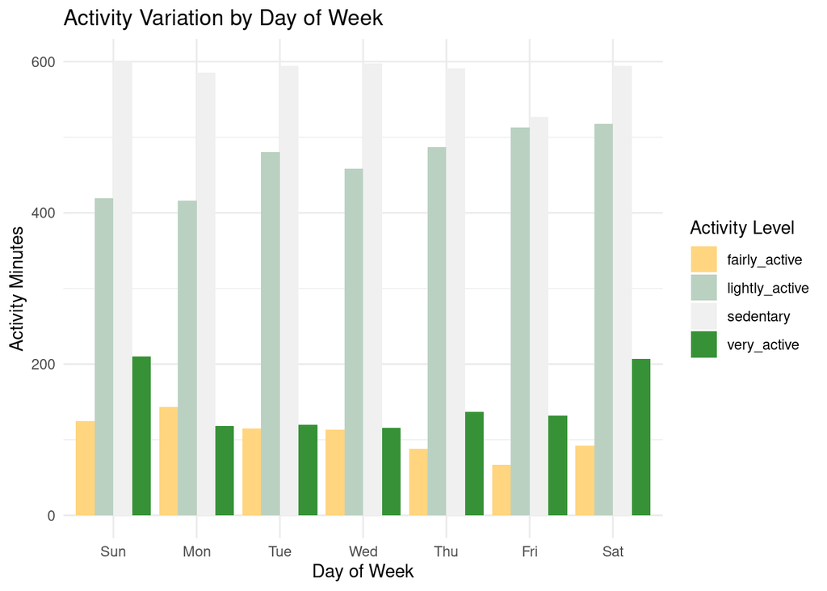

```r
ggplot(activity_summary_per_user_long, aes(x = weekday, y = `activity_minutes`, fill = `activity_level`)) +
  geom_bar(stat = "identity", position = "dodge") +
  labs(
    x = "Day of Week",
    y = "Activity Minutes",
    fill = "Activity Level",
    title = "Activity Variation by Day of Week"
  ) +
  scale_fill_manual(values = c( "lightly_active" = "#BAD1C2", "fairly_active" ="#FFD580"  , "very_active" = "#379237", "sedentary" = "#F0F0F0"))+
  theme_minimal() +
  ylim(0, 600)
```

#### Relationship between activity levels and calories burned

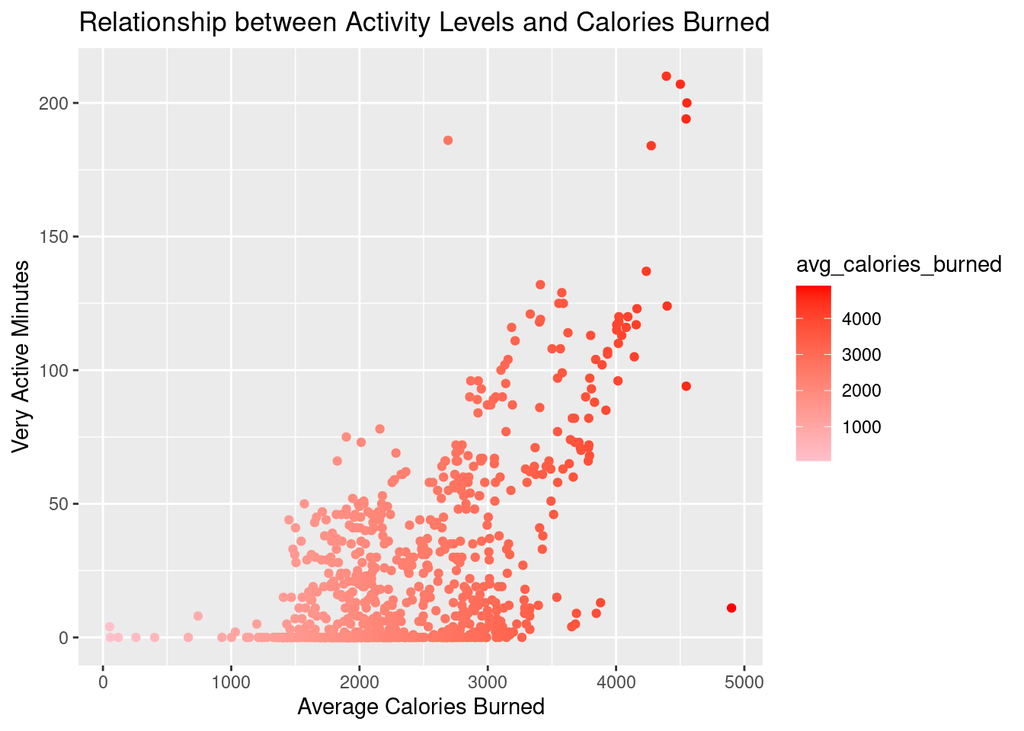

```r
ggplot(calories_vs_activity, aes(x = avg_calories_burned, y = (very_active_minutes), color = avg_calories_burned)) +
  geom_point() +
  labs(x = "Average Calories Burned", y = "Very Active Minutes") +
  ggtitle("Relationship between Activity Levels and Calories Burned") +
  scale_color_gradient(low = "pink", high = "red")
```

**The chart demonstrates a clear pattern: individuals who spend more time in very active minutes tend to burn more calories on average. This observation implies that engaging in higher levels of physical activity, particularly through intense active minutes, leads to a greater expenditure of calories.**

```r
percentage_manual <- weight_log %>%
  summarise(percentage = mean(is_manual_report) * 100)
print(percentage_manual)
```

```
## # A tibble: 1 × 1
##   percentage
##        <dbl>
## 1       61.2
```

#### Summary of weight and BMI

```r
weight_summary <- summary(weight_log$weight_pounds)
bmi_summary <- summary(weight_log$bmi)
```

```r
summary_data <- data.frame(
  Variable = c("Weight (lb)", "BMI"),
  Minimum = c(weight_summary[1], bmi_summary[1]),
  First_Quartile = c(weight_summary[2], bmi_summary[2]),
  Median = c(weight_summary[3], bmi_summary[3]),
  Mean = c(weight_summary[4], bmi_summary[4]),
  Third_Quartile = c(weight_summary[5], bmi_summary[5]),
  Maximum = c(weight_summary[6], bmi_summary[6])
)
print(summary_data)
```

```
##      Variable  Minimum First_Quartile   Median      Mean Third_Quartile
## 1 Weight (lb) 115.9631       135.3638 137.7889 158.81180       187.5032
## 2         BMI  21.4500        23.9600  24.3900  25.18522        25.5600
##    Maximum
## 1 294.3171
## 2  47.5400
```

In the provided code, I first use the summary() function on the “weight_pounds” variable and store the summary statistics in the weight_summary object. Similarly, I use the summary() function on the “bmi” variable and store the summary statistics in the bmi_summary object.Next, I create a data frame called summary_data to store the summary statistics for weight and BMI. The purpose of this code is to generate summary statistics for the weight and BMI variables in the weight log dataset and display them in a structured format for easy interpretation.

#### Calculate the total time asleep per day per user

```r
avg_sleep_duration_per_user <- minutes_sleep %>%
  mutate(value = as.numeric(value)) %>%
  group_by(id, date) %>%
  summarise(total_duration = sum(value, na.rm = TRUE), .groups = "drop")
print(avg_sleep_duration_per_user)
```

```
## # A tibble: 449 × 3
##            id date      total_duration
##         <dbl> <chr>              <dbl>
##  1 1503960366 4/12/2016            371
##  2 1503960366 4/13/2016            442
##  3 1503960366 4/15/2016            480
##  4 1503960366 4/16/2016            436
##  5 1503960366 4/17/2016            690
##  6 1503960366 4/19/2016            336
##  7 1503960366 4/20/2016            397
##  8 1503960366 4/21/2016            406
##  9 1503960366 4/23/2016            408
## 10 1503960366 4/24/2016            468
## # ℹ 439 more rows
```

In the provided code, I start by converting the “value” column in the “minutes_sleep” dataset to numeric using the as.numeric() function. Then, I group the data by “id” and “date” using the group_by() function. Next, I calculate the total duration of sleep for each user on each date by using the sum() function on the “value” column. The na.rm = TRUE argument is used to exclude any missing values in the calculation. The resulting aggregated values are stored in the “total_duration” column.

#### Grouping sleep duration into less 6h , between 6-9h & more than 9h

```r
avg_sleep_duration <- avg_sleep_duration_per_user %>%
  mutate(sleep_group = case_when(
    total_duration < 360 ~ "Less than 6 hours",
    total_duration >= 360 & total_duration <= 540 ~ "6-9 hours",
    total_duration > 540 ~ "More than 9 hours"
  ))
print(avg_sleep_duration)
```

```
## # A tibble: 449 × 4
##            id date      total_duration sleep_group
##         <dbl> <chr>              <dbl> <chr>
##  1 1503960366 4/12/2016            371 6-9 hours
##  2 1503960366 4/13/2016            442 6-9 hours
##  3 1503960366 4/15/2016            480 6-9 hours
##  4 1503960366 4/16/2016            436 6-9 hours
##  5 1503960366 4/17/2016            690 More than 9 hours
##  6 1503960366 4/19/2016            336 Less than 6 hours
##  7 1503960366 4/20/2016            397 6-9 hours
##  8 1503960366 4/21/2016            406 6-9 hours
##  9 1503960366 4/23/2016            408 6-9 hours
## 10 1503960366 4/24/2016            468 6-9 hours
## # ℹ 439 more rows
```

In the provided code, I start with the “avg_sleep_duration_per_user” dataset obtained from the previous code snippet. Then, I use the mutate() function to create a new column called “sleep_group”.

Based on the “total_duration” column, I categorize the sleep duration into three groups using the case_when() function:

If the total duration is less than 360 minutes (6 hours), the sleep group is set as “Less than 6 hours”. If the total duration is between 360 and 540 minutes (6-9 hours), the sleep group is set as “6-9 hours”. If the total duration is more than 540 minutes (9 hours), the sleep group is set as “More than 9 hours”. The resulting dataset, “avg_sleep_duration”, contains the user’s average sleep duration per date along with the corresponding sleep group.

#### Create a bar plot of sleep duration groups

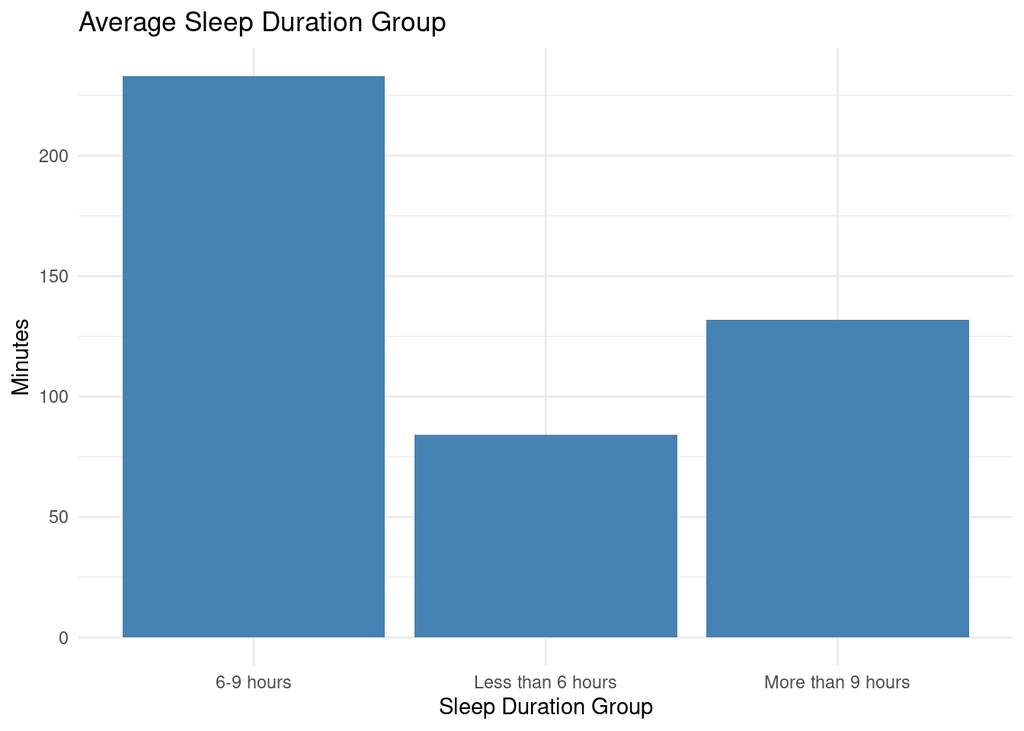

```r
ggplot(avg_sleep_duration, aes(x = sleep_group)) +
  geom_bar(fill = "steelblue") +
  labs(x = "Sleep Duration Group", y = "Minutes") +
  ggtitle("Average Sleep Duration Group") +
  theme_minimal()
```

#### Summary data daily steps

```r
steps_summary <- summary(daily_steps$step_total)
print(steps_summary)
```

```
##    Min. 1st Qu.  Median    Mean 3rd Qu.    Max.
##       0    3790    7406    7638   10727   36019
```

#### Summary steps to table

```r
summary_steps <- data.frame(
  Statistics = c("min", "first_quartile", "median", "mean", "third_quartile", "max"),
  Values = c(0, 3790, 7406, 7638, 10727, 36019)
)
print(summary_steps)
```

```
##       Statistics Values
## 1            min      0
## 2 first_quartile   3790
## 3         median   7406
## 4           mean   7638
## 5 third_quartile  10727
## 6            max  36019
```

In this code, I calculated the summary statistics for the “step_total” column in the “daily_steps” dataset. The resulting “steps_summary” object contains the minimum, first quartile, median, mean, third quartile, and maximum values of the step totals.

Then, I created a data frame called “summary_steps” to organize and present the summary statistics. The “Statistics” column includes labels for each statistic, such as “min” for minimum and “mean” for mean, and the “Values” column displays the corresponding values calculated from the dataset.

#### Activity variation - average steps

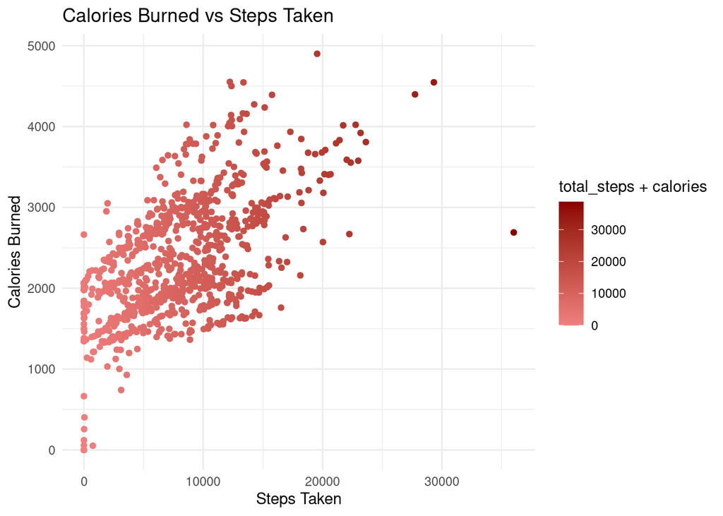

```r
ggplot(daily_activity, aes(x = total_steps, y = calories, color = total_steps + calories)) +
  geom_point() +
  scale_color_gradient(low = "lightcoral", high = "darkred") +
  labs(x = "Steps Taken", y = "Calories Burned") +
  ggtitle("Calories Burned vs Steps Taken") +
  theme_minimal()
```

**The scatter plot illustrates the relationship between the number of steps taken and the calories burned. As observed, there is a positive correlation between these two variables. The plot shows that as individuals take more steps, their calorie expenditure also increases. This finding suggests that physical activity, as represented by steps taken, plays a significant role in calorie burning.**

………………………………………………………………………..

## 5. Share

## Case Study Summary: Analysis and Recommendations for Bellabit Fitbit Product

## Based on the findings and trends observed in the analysis, here are some recommendations for Bellabit Fitbit product:

### Activity Tracking:

1. Encourage users to maintain consistent activity levels throughout the week by providing insights into their average steps, active minutes, active distance, and calories burned per weekday.
2. Promote activities that result in higher very active minutes, as they have a positive correlation with calories burned.

### Sleep Tracking:

1. Highlight the importance of total minutes asleep and total time in bed for overall well-being.
2. Provide personalized sleep recommendations to users based on their sleep patterns and encourage them to aim for a consistent and sufficient sleep duration.

### Weight Management:

1. Help users monitor their weight trends over time by visualizing the weight (kg) changes using line plots.
2. Provide insights into BMI distribution and educate users about healthy BMI ranges.
3. Offer personalized recommendations and resources for maintaining a healthy weight and achieving desired BMI goals.

### User Engagement:

1. Provide personalized recommendations and tips to users based on their activity.

## Conclusion

In this case study, I utilized R, a powerful tool for handling large datasets, performing data cleaning, conducting analysis, and creating visualizations, to analyze the Bellabit Fitbit product data. R was chosen due to its ability to handle substantial amounts of data and provide all the necessary functionalities in one place.

The analysis process began with data cleaning and preparation, including tasks such as standardizing column names and converting date formats. Exploratory data analysis techniques were then applied to uncover trends and gain insights from the dataset.

During the project, I encountered challenges, particularly in finding the correct syntax for specific calculations. However, I overcame these hurdles by leveraging online resources to learn the appropriate R functions and their effective usage. Additionally, these tools were helpful in explaining certain codes and providing ideas for identifying trends within the data. They also played a crucial role in summarizing findings and structuring the analysis.

While R initially appeared to be the most efficient tool for the project due to its ability to handle data cleaning, analysis, and visualizations, I discovered that working with R can be tedious. As a result, I have developed a preference for other tools that may offer a more streamlined workflow and improved user experience.